# logging_ros1_Jasper

# Set up

This is the logbook of the real resaurch of the real data.

For the data exploration, you can look in Ramons Logbook.

I wil begin an small annalzyse so first i need to read the counts in so can use them.

```r
count_data <- read.csv("/students/2025-2026/ros1_transcriptomics/output_new/counts.csv")
head(count_data)
```

```
##        X X10_S4_L001ReadsPerGene X11_S6_L001ReadsPerGene
## 1 TSPAN6                      22                      14
## 2   TNMD                       0                       0
## 3   DPM1                      27                      24
## 4  SCYL3                       8                       4
## 5  FIRRM                       6                       8
## 6    FGR                       0                       0
##   X12_S8_L001ReadsPerGene X1_S1_L001ReadsPerGene X2_S3_L001ReadsPerGene
## 1                      29                     32                     21
## 2                       0                      0                      0
## 3                      19                     42                     20
## 4                       5                      7                      5
## 5                       3                     19                      9
## 6                       0                      0                      0
##   X3_S5_L001ReadsPerGene X4_S7_L001ReadsPerGene X5_S9_L001ReadsPerGene
```

[output cut: 20 more lines]

```r
colnames(count_data)
```

```
##  [1] "X"                                "X10_S4_L001ReadsPerGene"
##  [3] "X11_S6_L001ReadsPerGene"          "X12_S8_L001ReadsPerGene"
##  [5] "X1_S1_L001ReadsPerGene"           "X2_S3_L001ReadsPerGene"
##  [7] "X3_S5_L001ReadsPerGene"           "X4_S7_L001ReadsPerGene"
##  [9] "X5_S9_L001ReadsPerGene"           "X6_S10_L001ReadsPerGene"
## [11] "X7_S11_L001ReadsPerGene"          "X8_S12_L001ReadsPerGene"
## [13] "X9_S2_L001ReadsPerGene"           "Undetermined_S0_L001ReadsPerGene"
```

I looked is the names are what i expected but it was not. read.csv does an check beacause names can not start with numbers in R so they put an x before it. So i need to use these for the coldata is wil make.

```r
coldata <- read.csv("/students/2025-2026/ros1_transcriptomics/output_new/coldata.csv",sep = ";")
head(coldata)
```

```
##                    source  condition
## 1  X1_S1_L001ReadsPerGene       DMSO
## 2  X2_S3_L001ReadsPerGene       DMSO
## 3  X3_S5_L001ReadsPerGene       DMSO
## 4  X4_S7_L001ReadsPerGene Lorlatinib
## 5  X5_S9_L001ReadsPerGene Lorlatinib
## 6 X6_S10_L001ReadsPerGene Lorlatinib
```

```r
row.names(coldata)
```

```
##  [1] "1"  "2"  "3"  "4"  "5"  "6"  "7"  "8"  "9"  "10" "11" "12"
```

The row names are wrong those need chancing first en need to remove Undetermined_S0_L001ReadsPerGene

```r
rownames(coldata) <- coldata$source
rownames(count_data) <- count_data$X
count_data <- count_data[, -1]
count_data <- count_data[,
    colnames(count_data) != "Undetermined_S0_L001ReadsPerGene"
]
```

```r
colnames(count_data)
```

```
##  [1] "X10_S4_L001ReadsPerGene" "X11_S6_L001ReadsPerGene"
##  [3] "X12_S8_L001ReadsPerGene" "X1_S1_L001ReadsPerGene"
##  [5] "X2_S3_L001ReadsPerGene"  "X3_S5_L001ReadsPerGene"
##  [7] "X4_S7_L001ReadsPerGene"  "X5_S9_L001ReadsPerGene"
##  [9] "X6_S10_L001ReadsPerGene" "X7_S11_L001ReadsPerGene"
## [11] "X8_S12_L001ReadsPerGene" "X9_S2_L001ReadsPerGene"
```

```r
rownames(coldata)
```

```
##  [1] "X1_S1_L001ReadsPerGene"  "X2_S3_L001ReadsPerGene"
##  [3] "X3_S5_L001ReadsPerGene"  "X4_S7_L001ReadsPerGene"
##  [5] "X5_S9_L001ReadsPerGene"  "X6_S10_L001ReadsPerGene"
##  [7] "X7_S11_L001ReadsPerGene" "X8_S12_L001ReadsPerGene"
##  [9] "X9_S2_L001ReadsPerGene"  "X10_S4_L001ReadsPerGene"
## [11] "X11_S6_L001ReadsPerGene" "X12_S8_L001ReadsPerGene"
```

Now all is good but need to chance the order in coldata

```r
coldata <- coldata[colnames(count_data), , drop = FALSE]
all(rownames(coldata) == colnames(count_data))
```

```
## [1] TRUE
```

I will make refenties so all wil go well

```r
coldata$condition <- factor(
  coldata$condition,
  levels = c("DMSO", "Lorlatinib", "Repotrectinib", "Zidesamtinib")
)
```

# All data

Now i wil start an desseq analsys for all so i can make an pca of all the data to look if it is well

```r
library("DESeq2")

dds <- DESeqDataSetFromMatrix(
    countData = count_data,
    colData = coldata,
    design = ~ condition
)

dds <- DESeq(dds)
```

```r
vsd <- vst(dds, blind = TRUE)
```

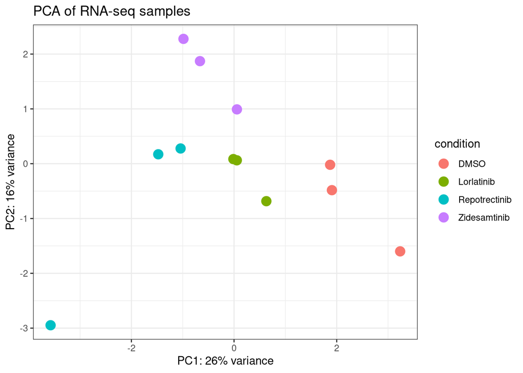

```r
pcaData <- plotPCA(vsd, intgroup = "condition", returnData = TRUE)

percentVar <- round(100 * attr(pcaData, "percentVar"))

library(ggplot2)

ggplot(pcaData, aes(PC1, PC2, color = condition)) +
    geom_point(size = 4) +
    xlab(paste0("PC1: ", percentVar[1], "% variance")) +
    ylab(paste0("PC2: ", percentVar[2], "% variance")) +
    ggtitle("PCA of RNA-seq samples")+
    theme_bw()
```

The destribution of all data point look good only the Repotrectinib as an big diffrence and need more research

i will make an new pca with names toe look wich file it is

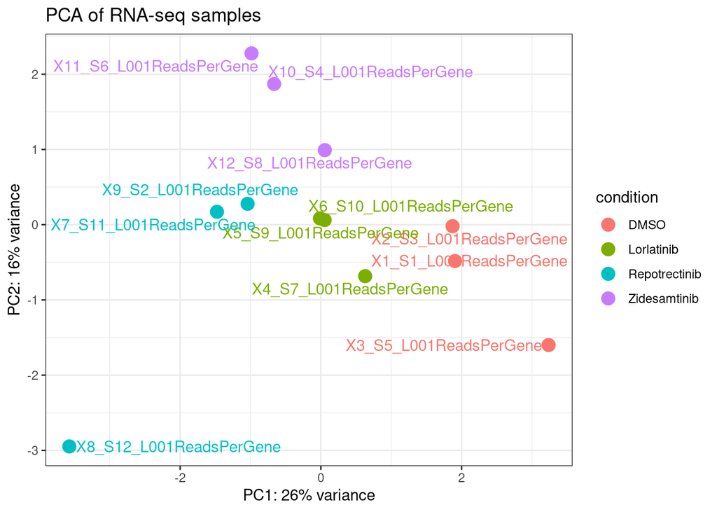

```r
library(ggrepel)

ggplot(pcaData, aes(PC1, PC2, color = condition, label = name)) +
    geom_point(size = 4) +
    geom_text_repel() +
    xlab(paste0("PC1: ", percentVar[1], "% variance")) +
    ylab(paste0("PC2: ", percentVar[2], "% variance")) +
    ggtitle("PCA of RNA-seq samples") +
    theme_bw()
```

I will make a heatmap so the differences between the samples can be shown.

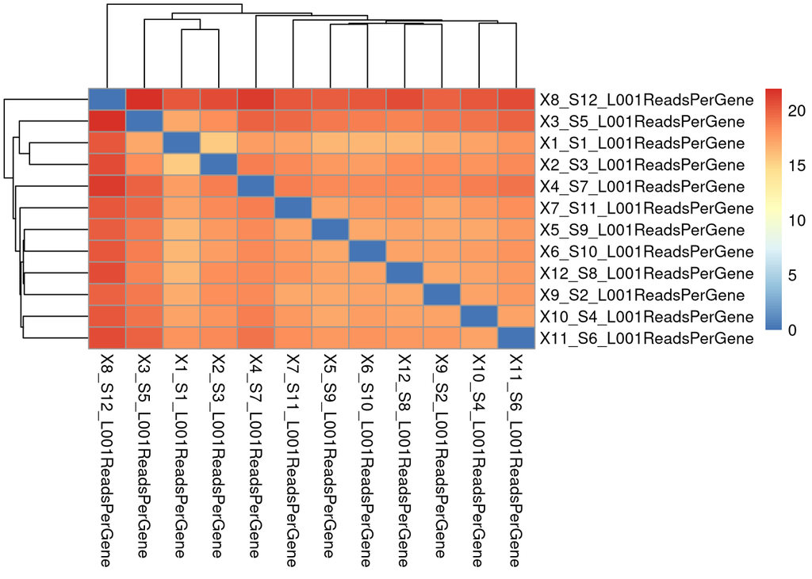

```r
sampleDists <- dist(t(assay(vsd)))
sampleDistMatrix <- as.matrix(sampleDists)

library(pheatmap)

pheatmap(sampleDistMatrix)
```

I will lookin de reads maby it can give an explanation.

```r
colSums(count_data)
```

```
## X10_S4_L001ReadsPerGene X11_S6_L001ReadsPerGene X12_S8_L001ReadsPerGene
##                  501331                  442358                  532967
##  X1_S1_L001ReadsPerGene  X2_S3_L001ReadsPerGene  X3_S5_L001ReadsPerGene
##                  816157                  552251                  406378
##  X4_S7_L001ReadsPerGene  X5_S9_L001ReadsPerGene X6_S10_L001ReadsPerGene
##                  354821                  510465                  488836
## X7_S11_L001ReadsPerGene X8_S12_L001ReadsPerGene  X9_S2_L001ReadsPerGene
##                  463039                  249445                  538753
```

# DMSO VS Lorlatinib

```r
res_Lorlatinib <- results(
    dds,
    contrast = c("condition", "Lorlatinib", "DMSO")
)
```

```r
summary(res_Lorlatinib)
```

```
##
## out of 22562 with nonzero total read count
## adjusted p-value < 0.1
## LFC > 0 (up)       : 6, 0.027%
## LFC < 0 (down)     : 6, 0.027%
## outliers [1]       : 0, 0%
## low counts [2]     : 16754, 74%
## (mean count < 16)
## [1] see 'cooksCutoff' argument of ?results
## [2] see 'independentFiltering' argument of ?results
```

The differential expression analysis between Lorlatinib and DMSO identified only a small number of significantly differentially expressed genes, with 6 upregulated and 6 downregulated genes at an adjusted p-value threshold of 0.1. No statistical outliers were detected. A large proportion of genes showed low read counts and were filtered during the analysis, which is expected due to the targeted sequencing approach used in this dataset. Overall, the results indicate relatively limited transcriptional differences between the two conditions.

```r
library(EnhancedVolcano)
EnhancedVolcano(
    res_Lorlatinib,

    lab = rownames(res_Lorlatinib),

    x = 'log2FoldChange',
    y = 'padj',

    title = 'Lorlatinib vs DMSO',

    pCutoff = 0.05,
    FCcutoff = 1,

    pointSize = 2.0,
    labSize = 3.0
)
```

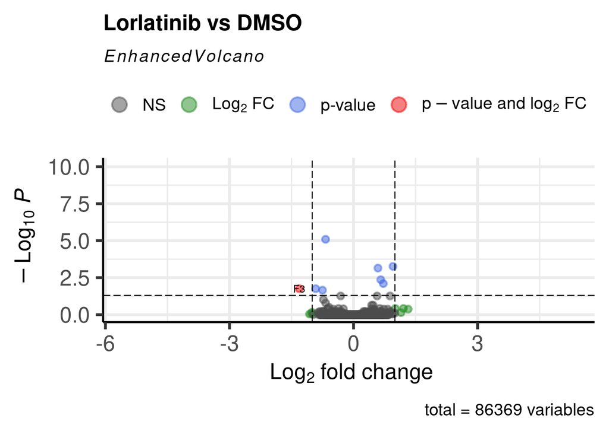

Only a limited number of genes were found to be significantly differentially expressed between the Lorlatinib and DMSO conditions. A large proportion of genes showed low counts, which is expected due to the targeted sequencing approach used in this experiment. Overall, the results suggest relatively modest transcriptional differences between the two conditions within the targeted gene panel.

```r
library(clusterProfiler)
library(org.Hs.eg.db)
library(enrichplot)
```

iw will slect the secnificant genses for an pathways analyszys

```r
sig_genes_Lorlatinib <- rownames(subset(res_Lorlatinib, padj < 0.1))
```

First the Go pathways

```r
ego_Lorlatinib <- enrichGO(
    gene          = sig_genes_Lorlatinib,
    OrgDb         = org.Hs.eg.db,
    keyType       = "SYMBOL",
    ont           = "BP",
    pAdjustMethod = "BH",
    pvalueCutoff  = 0.05,
    qvalueCutoff  = 0.2
)
head(ego_Lorlatinib)
```

```
##                    ID                 Description GeneRatio   BgRatio
## GO:0048545 GO:0048545 response to steroid hormone      4/11 338/18805
##            RichFactor FoldEnrichment   zScore       pvalue   p.adjust
## GO:0048545 0.01183432       20.23131 8.631392 3.062303e-05 0.01448469
##                 qvalue               geneID Count
## GO:0048545 0.008606682 ZMIZ1/HSPA8/JUND/JUN     4
```

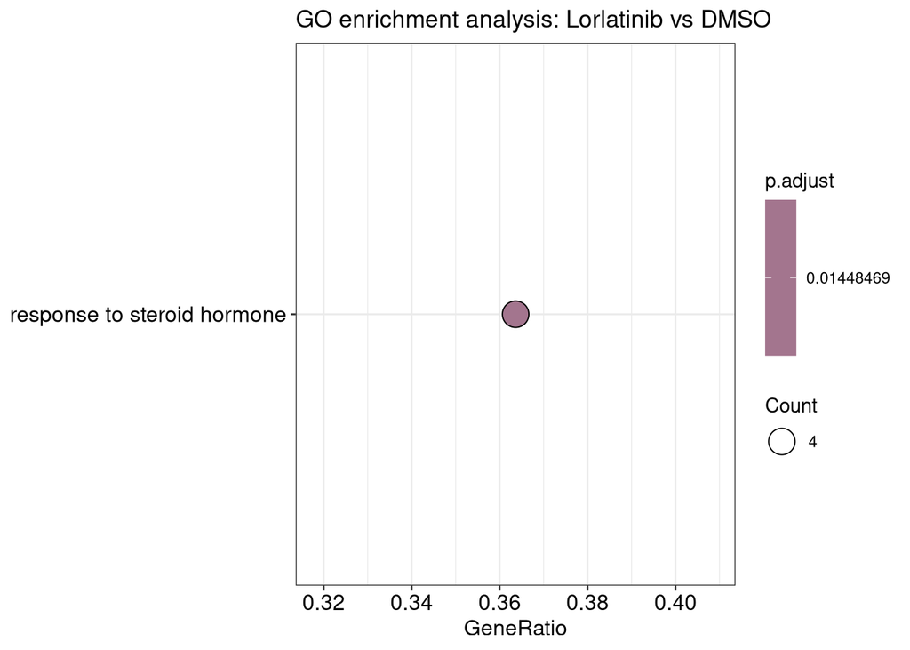

```r
dotplot(ego_Lorlatinib)+ggtitle("GO enrichment analysis: Lorlatinib vs DMSO")
```

Gene Ontology enrichment analysis identified “response to steroid hormone” as a significantly enriched biological process, suggesting that genes involved in hormone-responsive pathways may be affected by the treatment.

Now for kech patways

```r
gene_entrez_Lorlatinib <- bitr(
    sig_genes_Lorlatinib,
    fromType = "SYMBOL",
    toType = "ENTREZID",
    OrgDb = org.Hs.eg.db
)

ekegg_Lorlatinib <- enrichKEGG(
    gene = gene_entrez_Lorlatinib$ENTREZID,
    organism = "hsa"
)
```

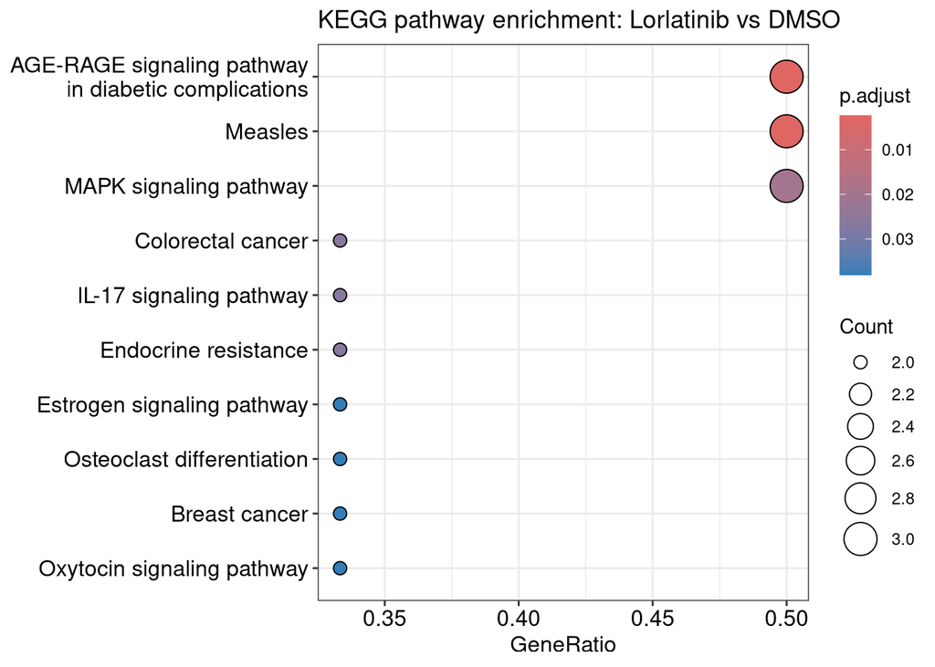

```r
dotplot(ekegg_Lorlatinib)+ggtitle("KEGG pathway enrichment: Lorlatinib vs DMSO")
```

KEGG pathway enrichment analysis revealed several significantly enriched pathways, including the MAPK signaling pathway, IL-17 signaling pathway, endocrine resistance, and AGE-RAGE signaling pathway in diabetic complications. These pathways are associated with cell signaling, inflammation, and cancer-related processes, indicating that the treatment may influence multiple regulatory and stress-response mechanisms.

# DMSO VS Repotrectinib

```r
res_Repotrectinib <- results(
    dds,
    contrast = c("condition", "Repotrectinib", "DMSO")
)
```

```r
summary(res_Repotrectinib)
```

```
##
## out of 22562 with nonzero total read count
## adjusted p-value < 0.1
## LFC > 0 (up)       : 26, 0.12%
## LFC < 0 (down)     : 39, 0.17%
## outliers [1]       : 0, 0%
## low counts [2]     : 18243, 81%
## (mean count < 24)
## [1] see 'cooksCutoff' argument of ?results
## [2] see 'independentFiltering' argument of ?results
```

The differential expression analysis between Repotrectinib and DMSO identified more significantly differentially expressed genes compared to the Lorlatinib comparison, with 26 upregulated and 39 downregulated genes at an adjusted p-value threshold of 0.1. No statistical outliers were detected. A large proportion of genes showed low read counts and were filtered during the analysis, which is consistent with the targeted sequencing approach used in this dataset. Overall, the results suggest that Repotrectinib induces a stronger transcriptional response compared to Lorlatinib under these experimental conditions.

```r
EnhancedVolcano(
    res_Repotrectinib,

    lab = rownames(res_Repotrectinib),

    x = 'log2FoldChange',
    y = 'padj',

    title = 'Repotrectinib vs DMSO',

    pCutoff = 0.05,
    FCcutoff = 1,

    pointSize = 2.0,
    labSize = 3.0
)
```

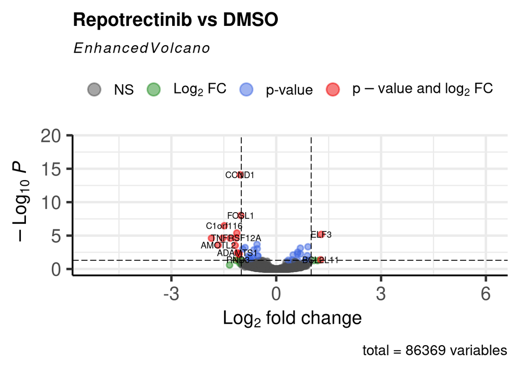

The volcano plot of Repotrectinib versus DMSO shows a larger number of significantly differentially expressed genes compared to the Lorlatinib comparison. Several genes display both significant adjusted p-values and notable log2 fold changes, indicating a stronger transcriptional response to Repotrectinib treatment. Most genes remain centered around a log2 fold change of zero, suggesting that the majority of genes are not strongly affected. Overall, the results indicate that Repotrectinib induces more pronounced gene expression changes under these experimental conditions.

```r
sig_genes_Repotrectinib <- rownames(subset(res_Repotrectinib, padj < 0.1))
```

First the Go pathways

```r
ego_Repotrectinib <- enrichGO(
    gene          = sig_genes_Repotrectinib,
    OrgDb         = org.Hs.eg.db,
    keyType       = "SYMBOL",
    ont           = "BP",
    pAdjustMethod = "BH",
    pvalueCutoff  = 0.05,
    qvalueCutoff  = 0.2
)
head(ego_Repotrectinib)
```

```
##                    ID                                    Description GeneRatio
## GO:0061614 GO:0061614                            miRNA transcription      6/64
## GO:1902895 GO:1902895     positive regulation of miRNA transcription      5/64
## GO:0097193 GO:0097193          intrinsic apoptotic signaling pathway      9/64
## GO:0010586 GO:0010586                        miRNA metabolic process      6/64
## GO:2000630 GO:2000630 positive regulation of miRNA metabolic process      5/64
## GO:0045765 GO:0045765                     regulation of angiogenesis      9/64
##              BgRatio RichFactor FoldEnrichment    zScore       pvalue
## GO:0061614  77/18805 0.07792208      22.895698 11.250639 2.400202e-07
## GO:1902895  56/18805 0.08928571      26.234654 11.051495 1.301196e-06
## GO:0097193 330/18805 0.02727273       8.013494  7.511349 1.668658e-06
## GO:0010586 110/18805 0.05454545      16.026989  9.236859 1.987012e-06
## GO:2000630  67/18805 0.07462687      21.927472 10.027930 3.196564e-06
## GO:0045765 363/18805 0.02479339       7.284995  7.065989 3.641173e-06
##                p.adjust       qvalue
## GO:0061614 0.0004536382 0.0003254169
## GO:1902895 0.0009388632 0.0006734925
## GO:0097193 0.0009388632 0.0006734925
## GO:0010586 0.0009388632 0.0006734925
## GO:2000630 0.0011469696 0.0008227774
## GO:0045765 0.0011469696 0.0008227774
##                                                         geneID Count
## GO:0061614                     HIF1A/DDX5/FOXA1/ETS1/MYC/FOSL1     6
## GO:1902895                          HIF1A/FOXA1/ETS1/MYC/FOSL1     5
## GO:0097193 BCL3/HIF1A/DDX5/MYC/CYP1B1/EPHA2/BCL2L11/DDIT4/CYCS     9
## GO:0010586                     HIF1A/DDX5/FOXA1/ETS1/MYC/FOSL1     6
## GO:2000630                          HIF1A/FOXA1/ETS1/MYC/FOSL1     5
## GO:0045765 HIF1A/F3/ETS1/THBS1/CYP1B1/EPHA2/HSPG2/PLK2/ADAMTS1     9
```

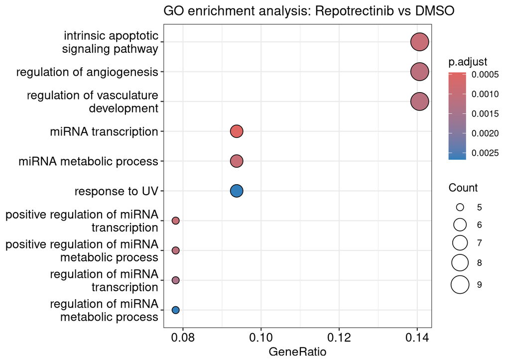

```r
dotplot(ego_Repotrectinib)+  ggtitle("GO enrichment analysis: Repotrectinib vs DMSO")
```

```r
gene_entrez_Repotrectinib <- bitr(
    sig_genes_Repotrectinib,
    fromType = "SYMBOL",
    toType = "ENTREZID",
    OrgDb = org.Hs.eg.db
)

ekegg_Repotrectinib <- enrichKEGG(
    gene = gene_entrez_Repotrectinib$ENTREZID,
    organism = "hsa"
)
```

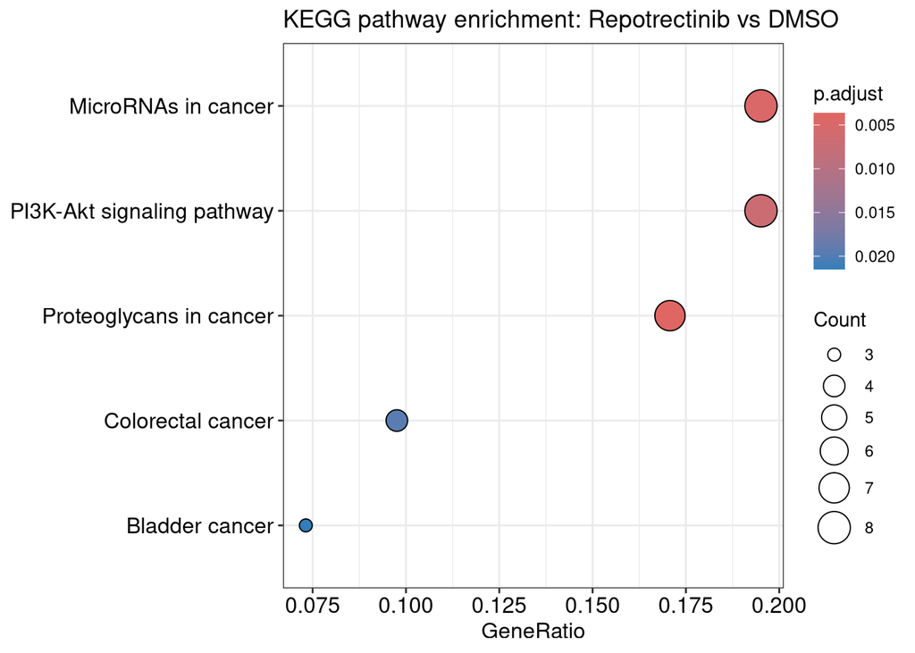

```r
dotplot(ekegg_Repotrectinib)+ggtitle("KEGG pathway enrichment: Repotrectinib vs DMSO")
```

The KEGG pathway enrichment analysis identified several significantly enriched cancer-related signaling pathways, including the PI3K-Akt signaling pathway and MicroRNAs in cancer. Additional enriched pathways, such as Proteoglycans in cancer and Colorectal cancer, are associated with tumor progression, cell survival, and cellular signaling. These results suggest that the treatment may influence pathways involved in cancer development and regulatory signaling mechanisms.

# DMSO VS Zidesamtinib

```r
res_Zidesamtinib <- results(
    dds,
    contrast = c("condition", "Zidesamtinib", "DMSO")
)
```

```r
summary(res_Zidesamtinib)
```

```
##
## out of 22562 with nonzero total read count
## adjusted p-value < 0.1
## LFC > 0 (up)       : 12, 0.053%
## LFC < 0 (down)     : 13, 0.058%
## outliers [1]       : 0, 0%
## low counts [2]     : 18243, 81%
## (mean count < 24)
## [1] see 'cooksCutoff' argument of ?results
## [2] see 'independentFiltering' argument of ?results
```

The differential expression analysis identified a limited number of significantly differentially expressed genes, with 12 upregulated and 13 downregulated genes at an adjusted p-value threshold of 0.1. No statistical outliers were detected in the dataset. A large proportion of genes showed low read counts and were filtered during the analysis, which is expected due to the targeted sequencing approach used in this study. Overall, the results indicate moderate transcriptional differences between the compared conditions.

```r
EnhancedVolcano(
    res_Zidesamtinib,

    lab = rownames(res_Zidesamtinib),

    x = 'log2FoldChange',
    y = 'padj',

    title = 'Zidesamtinib vs DMSO',

    pCutoff = 0.05,
    FCcutoff = 1,

    pointSize = 2.0,
    labSize = 3.0
)
```

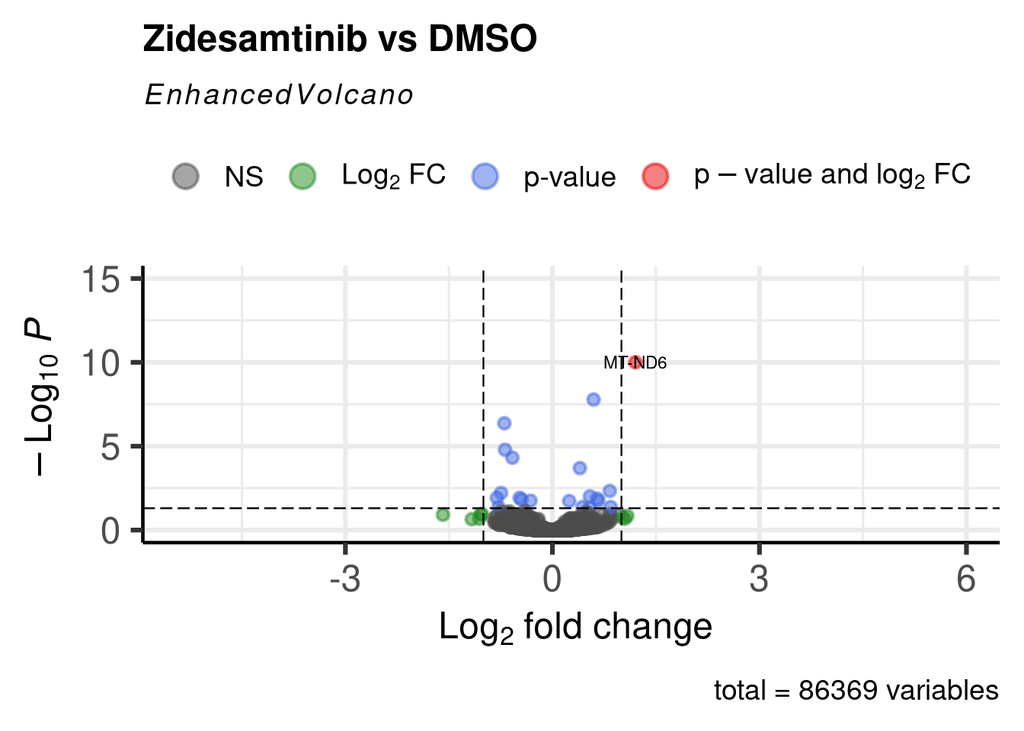

The volcano plot of Zidesamtinib versus DMSO shows a relatively small number of significantly differentially expressed genes. Most genes are centered around a log2 fold change of zero, indicating limited overall transcriptional changes between the two conditions. A few genes show stronger statistical significance and fold changes, with MTND6 being one of the most prominent differentially expressed genes. Overall, the results suggest that Zidesamtinib induces moderate transcriptional effects under these experimental conditions.

```r
sig_genes_Zidesamtinib <- rownames(subset(res_Zidesamtinib, padj < 0.1))
```

First the Go pathways

```r
ego_Zidesamtinib <- enrichGO(
    gene          = sig_genes_Zidesamtinib,
    OrgDb         = org.Hs.eg.db,
    keyType       = "SYMBOL",
    ont           = "BP",
    pAdjustMethod = "BH",
    pvalueCutoff  = 0.05,
    qvalueCutoff  = 0.2
)
head(ego_Zidesamtinib)
```

```
##                    ID
## GO:0002181 GO:0002181
## GO:1901798 GO:1901798
## GO:1901796 GO:1901796
## GO:0006119 GO:0006119
## GO:0072331 GO:0072331
## GO:1902600 GO:1902600
##                                                                 Description
## GO:0002181                                          cytoplasmic translation
## GO:1901798 positive regulation of signal transduction by p53 class mediator
## GO:1901796          regulation of signal transduction by p53 class mediator
## GO:0006119                                        oxidative phosphorylation
## GO:0072331                        signal transduction by p53 class mediator
## GO:1902600                                   proton transmembrane transport
##            GeneRatio   BgRatio RichFactor FoldEnrichment    zScore       pvalue
## GO:0002181      5/21 169/18805 0.02958580       26.49338 11.131024 1.000637e-06
## GO:1901798      3/21  27/18805 0.11111111       99.49735 17.124682 3.450579e-06
## GO:1901796      4/21 106/18805 0.03773585       33.79155 11.320001 5.301482e-06
## GO:0006119      4/21 151/18805 0.02649007       23.72122  9.372920 2.149719e-05
## GO:0072331      4/21 165/18805 0.02424242       21.70851  8.933233 3.044297e-05
## GO:1902600      4/21 190/18805 0.02105263       18.85213  8.269439 5.281977e-05
##                p.adjust       qvalue                       geneID Count
## GO:0002181 0.0005663608 0.0003970951 RPS15/RPL37/RPL9/RPS27/RPS29     5
## GO:1901798 0.0009765138 0.0006846675             DDX5/RPS15/RPL37     3
## GO:1901796 0.0010002130 0.0007012838        DDX5/RPS15/SOX4/RPL37     4
## GO:0006119 0.0030418527 0.0021327478 MT-ND6/MT-CYB/MT-ND4/MT-ATP6     4
## GO:0072331 0.0034461445 0.0024162106        DDX5/RPS15/SOX4/RPL37     4
## GO:1902600 0.0046416734 0.0032544372 MT-ND6/MT-CYB/MT-ND4/MT-ATP6     4
```

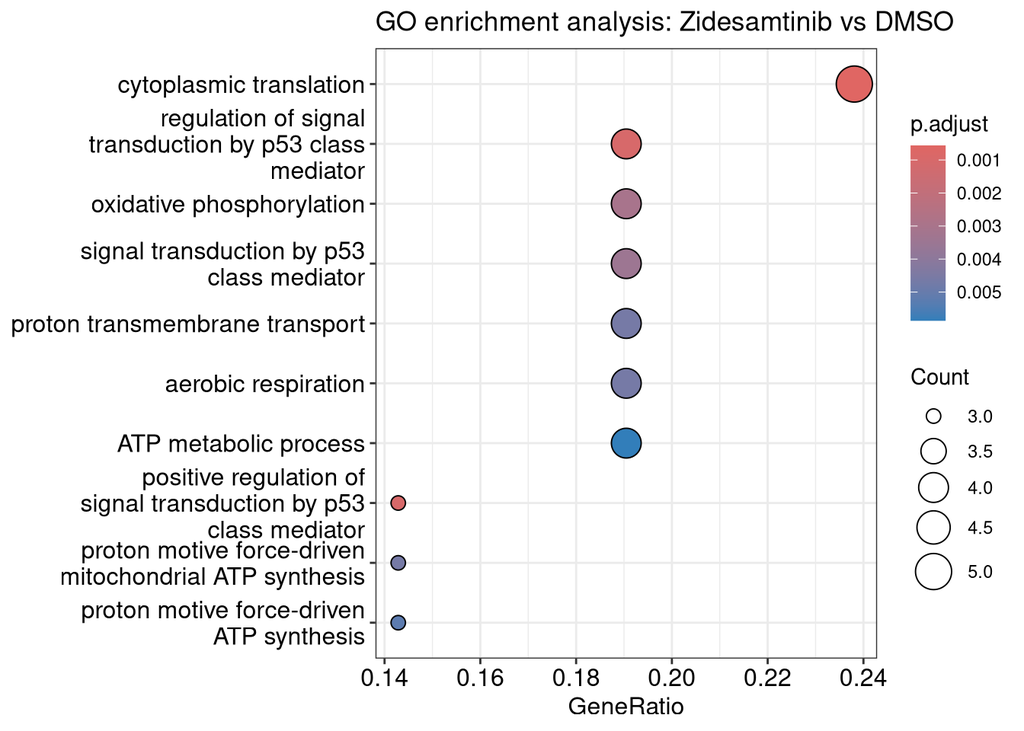

```r
dotplot(ego_Zidesamtinib)+  ggtitle("GO enrichment analysis: Zidesamtinib vs DMSO")
```

The Gene Ontology enrichment analysis for Zidesamtinib versus DMSO identified several significantly enriched biological processes related to cellular energy metabolism and p53-mediated signaling. Enriched pathways included oxidative phosphorylation, aerobic respiration, ATP metabolic processes, and proton transmembrane transport, suggesting that the treatment may influence mitochondrial activity and energy production. In addition, enrichment of p53 class mediator signaling pathways indicates potential involvement of stress-response and regulatory mechanisms associated with cell cycle control and apoptosis.

```r
gene_entrez_Zidesamtinib <- bitr(
    sig_genes_Zidesamtinib,
    fromType = "SYMBOL",
    toType = "ENTREZID",
    OrgDb = org.Hs.eg.db
)

ekegg_Zidesamtinib <- enrichKEGG(
    gene = gene_entrez_Zidesamtinib$ENTREZID,
    organism = "hsa"
)
```

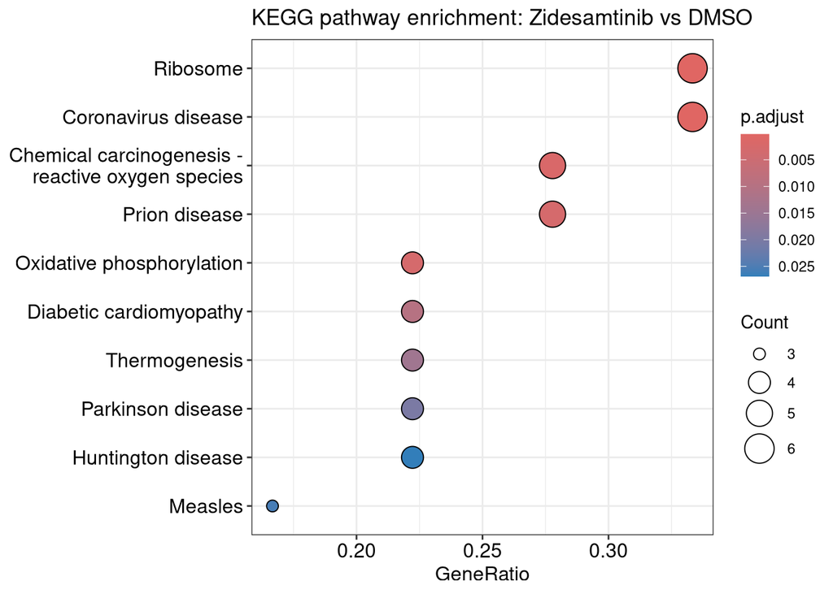

```r
dotplot(ekegg_Zidesamtinib)+ggtitle("KEGG pathway enrichment: Zidesamtinib vs DMSO")
```

The KEGG pathway enrichment analysis for Zidesamtinib versus DMSO identified several significantly enriched pathways associated with ribosomal activity, oxidative phosphorylation, and reactive oxygen species. Pathways related to mitochondrial and neurodegenerative disease processes, including Parkinson disease and Huntington disease, were also enriched, which is commonly linked to alterations in cellular energy metabolism and mitochondrial function. In addition, enrichment of pathways related to thermogenesis and chemical carcinogenesis suggests broader effects on metabolic and stress-response mechanisms. Overall, these results indicate that Zidesamtinib may strongly influence mitochondrial activity and cellular metabolic regulation.

# First conclusion

Overall, the results suggest that the different ROS1 inhibitors induce distinct transcriptional responses in the CD74-ROS1 model, with Repotrectinib showing the most pronounced global gene expression changes under the tested conditions.